# Functional Programming with purrr

17 April 2019

## Overview

- Why should I care about functional programming or `purrr`?
- What can I do with these tools?
- Where can I learn more?

## Why should I care?

## Three ideas

1. The easier code is to understand, the better.
2. The easier code is to reuse and adapt, the better.
3. The more reliable my results from code, the better.

## Functions

### What is a function?

```r
square <- function(x) {
    return(x^2)
}
```

## Functions

```r
square(c(1, 2, 3, 4, 5))
```

```
## [1]  1  4  9 16 25
```

## The Pipe

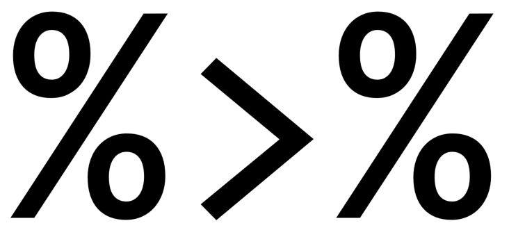

## The Pipe

```r
c(1, 2, 3, 4, 5) %>%
    square()
```

```
## [1]  1  4  9 16 25
```

## The easier code is to understand, the better

## What is Functional Programming?

### Functional Programming …

> … treats computation as the evaluation of mathematical functions …

> … avoids changing state and side effects …

> … avoids mutable data …

## The easier code is to understand, the better

```r
map()
```

## The easier code is to understand, the better

```r
map(list(1, 2, 3, 4, 5))
```

## The easier code is to understand, the better

```r
map(list(1, 2, 3, 4, 5), square)
```

## The easier code is to understand, the better

```r
map(list(1, 2, 3, 4, 5), square)
```

```
## [[1]]
## [1] 1
##
## [[2]]
## [1] 4
##
## [[3]]
## [1] 9
##
## [[4]]
## [1] 16
##
## [[5]]
## [1] 25
```

## The easier code is to understand, the better

```r
list(c(1),
     c(2, 3, 4),
     c(5, 6)) %>%
    map(square)
```

```
## [[1]]
## [1] 1
##
## [[2]]
## [1]  4  9 16
##
## [[3]]
## [1] 25 36
```

## The easier code is to reuse and adapt, the better

## The easier code is to reuse and adapt, the better

```r
# Generate a sample dataset
set.seed(1014)
df <- data.frame(replicate(6, sample(c(1:10, -99), 6, rep = TRUE)))
names(df) <- letters[1:6]
df
```

```
##    a  b c   d   e f
## 1  1  6 1   5 -99 1
## 2 10  4 4 -99   9 3
## 3  7  9 5   4   1 4
## 4  2  9 3   8   6 8
## 5  1 10 5   9   8 6
## 6  6  2 1   3   8 5
```

Source: [Hadley Wickham, Advanced R](http://adv-r.had.co.nz/Functional-programming.html#fp-motivation)

## The easier code is to reuse and adapt, the better

```r
df$a[df$a == -99] <- NA
df$b[df$b == -99] <- NA
df$c[df$c == -98] <- NA
df$d[df$d == -99] <- NA
df$e[df$e == -99] <- NA
df$f[df$g == -99] <- NA
```

## The easier code is to reuse and adapt, the better

```r
fix_missing <- function(x) {
    x[x == -99] <- NA
    x
}
df$a <- fix_missing(df$a)
df$b <- fix_missing(df$b)
df$c <- fix_missing(df$c)
df$d <- fix_missing(df$d)
df$e <- fix_missing(df$e)
df$f <- fix_missing(df$e)
```

## The easier code is to reuse and adapt, the better

```r
fix_missing <- function(x) {
    x[x == -99] <- NA
    x
}

df %>%
    map(fix_missing)
```

```
## $a
## [1]  1 10  7  2  1  6
##
## $b
## [1]  6  4  9  9 10  2
##
## $c
## [1] 1 4 5 3 5 1
##
## $d
## [1]  5 NA  4  8  9  3
##
## $e
## [1] NA  9  1  6  8  8
##
## $f
## [1] 1 3 4 8 6 5
```

## The easier code is to reuse and adapt, the better

```r
df %>%
    map(fix_missing) %>%
    as.data.frame()
```

```
##    a  b c  d  e f
## 1  1  6 1  5 NA 1
## 2 10  4 4 NA  9 3
## 3  7  9 5  4  1 4
## 4  2  9 3  8  6 8
## 5  1 10 5  9  8 6
## 6  6  2 1  3  8 5
```

## The more reliable my results from code, the better

## Question …

#### Do you expect code to give the same results every time?

## Impure Functions

### `Sys.Date()`

### `rnorm(1)`

### `plot()`

## The more reliable my results from code, the better

```r
clean_df <- df %>%
    map(fix_missing) %>%
    as.data.frame()
clean_df
```

```
##    a  b c  d  e f
## 1  1  6 1  5 NA 1
## 2 10  4 4 NA  9 3
## 3  7  9 5  4  1 4
## 4  2  9 3  8  6 8
## 5  1 10 5  9  8 6
## 6  6  2 1  3  8 5
```

## What can we do with these tools?

## The German Credit Dataset

```r
d <- read_rds("./data/clean/german_credit_cleaned.rds")
head(d) %>%
    select(acct_status, duration, outcome) %>%
    knitr::kable()
```

| acct_status | duration | outcome |
| --- | --- | --- |
| overdrawn | 6 | good |
| below_200DM | 48 | bad |
| no_acct | 12 | good |
| overdrawn | 42 | good |
| overdrawn | 24 | bad |
| no_acct | 36 | good |

## `glmnet`

- Standard logistic regression, plus …
- A penalty for considering variables to be too important.
- Helps the model to generalise to new data.

## `glmnet`

### Two elements to the penalty

1. `lambda`: the **strength** of the penalty
2. `alpha`: the **type** of penalty

Want to:

- Test \(\alpha = \{0.0, 0.05, 0.10, ... , 1.0\}\), and
- Have the results in a useful format.

We will do this with functional programming and `purrr`!

## Data Loading and Partition

```r
X <- model.matrix(outcome ~ 0 + .,
                  data = d) %>%
    scale()
y <- if_else(d$outcome == "bad", 1L, 0L)
```

## Data Loading and Partition

```r
random_seed <- 1054
set.seed(random_seed)
train_idx <- createDataPartition(y,
                                 p = 0.8,
                                 list = FALSE)
Xtrain <- X[train_idx, ]
Xtest <- X[-train_idx, ]
ytrain <- y[train_idx]
ytest <- y[-train_idx]
```

## Data Loading and Partition

```r
set.seed(random_seed)
cv_folds <- createFolds(ytrain,
                        k = 10,
                        list = FALSE)
head(cv_folds)
```

```
## [1] 10  5  8  3 10  9
```

## Model Training

```r
tibble(alpha = seq(0, 1, 0.05))
```

```
## # A tibble: 21 x 1
##    alpha
##    <dbl>
##  1  0
##  2  0.05
##  3  0.1
##  4  0.15
##  5  0.2
##  6  0.25
##  7  0.3
##  8  0.35
##  9  0.4
## 10  0.45
## # … with 11 more rows
```

## Model Training

```r
trained_models <- tibble(
    alpha = seq(0, 1, 0.05)
) %>%
    mutate(model = map(alpha,
                       ~ cv.glmnet(Xtrain,
                                   ytrain,
                                   family = "binomial",
                                   foldid = cv_folds,
                                   alpha = .x))
    )
trained_models
```

```
## # A tibble: 21 x 2
##    alpha model
##    <dbl> <list>
##  1  0    <S3: cv.glmnet>
##  2  0.05 <S3: cv.glmnet>
##  3  0.1  <S3: cv.glmnet>
##  4  0.15 <S3: cv.glmnet>
##  5  0.2  <S3: cv.glmnet>
##  6  0.25 <S3: cv.glmnet>
##  7  0.3  <S3: cv.glmnet>
##  8  0.35 <S3: cv.glmnet>
##  9  0.4  <S3: cv.glmnet>
## 10  0.45 <S3: cv.glmnet>
## # … with 11 more rows
```

## Training Results

### To get results we need:

- A way to measure prediction error;
- To tell `glmnet` which value of `lambda` to use:
- `"lambda.min"`, or
- `"lambda.1se"`

## Training Results

### Build up the results step by step

```r
c("lambda.min", "lambda.1se") %>%
    map(~ trained_models)
```

## Training Results

```r
c("lambda.min", "lambda.1se") %>%
    map(~ trained_models %>%
            mutate(lambda = .x))
```

```
## [[1]]
## # A tibble: 21 x 3
##    alpha model           lambda
##    <dbl> <list>          <chr>
##  1  0    <S3: cv.glmnet> lambda.min
##  2  0.05 <S3: cv.glmnet> lambda.min
##  3  0.1  <S3: cv.glmnet> lambda.min
##  4  0.15 <S3: cv.glmnet> lambda.min
##  5  0.2  <S3: cv.glmnet> lambda.min
##  6  0.25 <S3: cv.glmnet> lambda.min
##  7  0.3  <S3: cv.glmnet> lambda.min
##  8  0.35 <S3: cv.glmnet> lambda.min
##  9  0.4  <S3: cv.glmnet> lambda.min
## 10  0.45 <S3: cv.glmnet> lambda.min
## # … with 11 more rows
##
## [[2]]
## # A tibble: 21 x 3
##    alpha model           lambda
##    <dbl> <list>          <chr>
##  1  0    <S3: cv.glmnet> lambda.1se
##  2  0.05 <S3: cv.glmnet> lambda.1se
##  3  0.1  <S3: cv.glmnet> lambda.1se
##  4  0.15 <S3: cv.glmnet> lambda.1se
##  5  0.2  <S3: cv.glmnet> lambda.1se
##  6  0.25 <S3: cv.glmnet> lambda.1se
##  7  0.3  <S3: cv.glmnet> lambda.1se
##  8  0.35 <S3: cv.glmnet> lambda.1se
##  9  0.4  <S3: cv.glmnet> lambda.1se
## 10  0.45 <S3: cv.glmnet> lambda.1se
## # … with 11 more rows
```

## Training Results

```r
c("lambda.min", "lambda.1se") %>%
    map_dfr(~ trained_models %>%
                mutate(lambda = .x))
```

```
## # A tibble: 42 x 3
##    alpha model           lambda
##    <dbl> <list>          <chr>
##  1  0    <S3: cv.glmnet> lambda.min
##  2  0.05 <S3: cv.glmnet> lambda.min
##  3  0.1  <S3: cv.glmnet> lambda.min
##  4  0.15 <S3: cv.glmnet> lambda.min
##  5  0.2  <S3: cv.glmnet> lambda.min
##  6  0.25 <S3: cv.glmnet> lambda.min
##  7  0.3  <S3: cv.glmnet> lambda.min
##  8  0.35 <S3: cv.glmnet> lambda.min
##  9  0.4  <S3: cv.glmnet> lambda.min
## 10  0.45 <S3: cv.glmnet> lambda.min
## # … with 32 more rows
```

## `purrr` type error

```r
c("lambda.min", "lambda.1se") %>%
    map_int(~ trained_models %>%
                mutate(lambda = .x))
```

```
## Error: Result 1 must be a single integer, not a vector of class `tbl_df/tbl/data.frame` and of length 3
```

## `purrr` type error

```r
list(c(1, 2, 3),
     c(4, 5),
     c(6)) %>%
    map_dbl(max)
```

```
## [1] 3 5 6
```

```r
list(c(1, 2, 3),
     c(4, 5),
     c(6)) %>%
    map_int(max)
```

```
## Error: Can't coerce element 1 from a double to a integer
```

## Training Results

```r
c("lambda.min", "lambda.1se") %>%
    map_dfr(
        ~ trained_models %>%
            mutate(lambda = .x) %>%
            mutate(train_preds = map2(model,
                                      lambda,
                                      ~ predict(.x,
                                                newx = Xtrain,
                                                type = "response",
                                                s = .y)))
    )
```

```
## # A tibble: 42 x 4
##    alpha model           lambda     train_preds
##    <dbl> <list>          <chr>      <list>
##  1  0    <S3: cv.glmnet> lambda.min <dbl [800 × 1]>
##  2  0.05 <S3: cv.glmnet> lambda.min <dbl [800 × 1]>
##  3  0.1  <S3: cv.glmnet> lambda.min <dbl [800 × 1]>
##  4  0.15 <S3: cv.glmnet> lambda.min <dbl [800 × 1]>
##  5  0.2  <S3: cv.glmnet> lambda.min <dbl [800 × 1]>
##  6  0.25 <S3: cv.glmnet> lambda.min <dbl [800 × 1]>
##  7  0.3  <S3: cv.glmnet> lambda.min <dbl [800 × 1]>
##  8  0.35 <S3: cv.glmnet> lambda.min <dbl [800 × 1]>
##  9  0.4  <S3: cv.glmnet> lambda.min <dbl [800 × 1]>
## 10  0.45 <S3: cv.glmnet> lambda.min <dbl [800 × 1]>
## # … with 32 more rows
```

## Error Function

```r
binom_deviance <- function(pred,
                           actual) {
    mean(2 * (dplyr::coalesce(actual * log(actual/pred), 0) +
                  dplyr::coalesce((1 - actual) *
                                      log((1 - actual)/(1 - pred)),
                                  0)))
}
```

## Training Results

```r
train_results <- c("lambda.min", "lambda.1se") %>%
    map_dfr(
        ~ trained_models %>%
            mutate(lambda = .x) %>%
            mutate(train_preds = map2(model,
                                      lambda,
                                      ~ predict(.x,
                                                newx = Xtrain,
                                                type = "response",
                                                s = .y))) %>%
            mutate(train_dev = map_dbl(train_preds,
                                       binom_deviance,
                                       actual = ytrain))
    )
```

## Training Results

```r
train_results
```

```
## # A tibble: 42 x 5
##    alpha model           lambda     train_preds     train_dev
##    <dbl> <list>          <chr>      <list>              <dbl>
##  1  0    <S3: cv.glmnet> lambda.min <dbl [800 × 1]>     0.920
##  2  0.05 <S3: cv.glmnet> lambda.min <dbl [800 × 1]>     0.918
##  3  0.1  <S3: cv.glmnet> lambda.min <dbl [800 × 1]>     0.919
##  4  0.15 <S3: cv.glmnet> lambda.min <dbl [800 × 1]>     0.920
##  5  0.2  <S3: cv.glmnet> lambda.min <dbl [800 × 1]>     0.919
##  6  0.25 <S3: cv.glmnet> lambda.min <dbl [800 × 1]>     0.921
##  7  0.3  <S3: cv.glmnet> lambda.min <dbl [800 × 1]>     0.921
##  8  0.35 <S3: cv.glmnet> lambda.min <dbl [800 × 1]>     0.922
##  9  0.4  <S3: cv.glmnet> lambda.min <dbl [800 × 1]>     0.931
## 10  0.45 <S3: cv.glmnet> lambda.min <dbl [800 × 1]>     0.938
## # … with 32 more rows
```

## Plot training error

```r
train_results %>%
    ggplot(aes(alpha, train_dev, colour = lambda)) +
    geom_point(size = 2) +
    scale_colour_viridis_d(end = 0.7,
                           option = "B") +
    scale_y_continuous("Mean Training Deviance") +
    scale_x_continuous(expression(alpha),
                       breaks = c(0, 0.5, 1),
                       labels = c("Ridge", "Elastic", "LASSO")) +
    ggtitle("Training Error by Penalty Type",
            subtitle = "LASSO, Ridge, Elastic Net Regression") +
    theme_classic() +
    theme(legend.title = element_blank())
```

## Plot training error

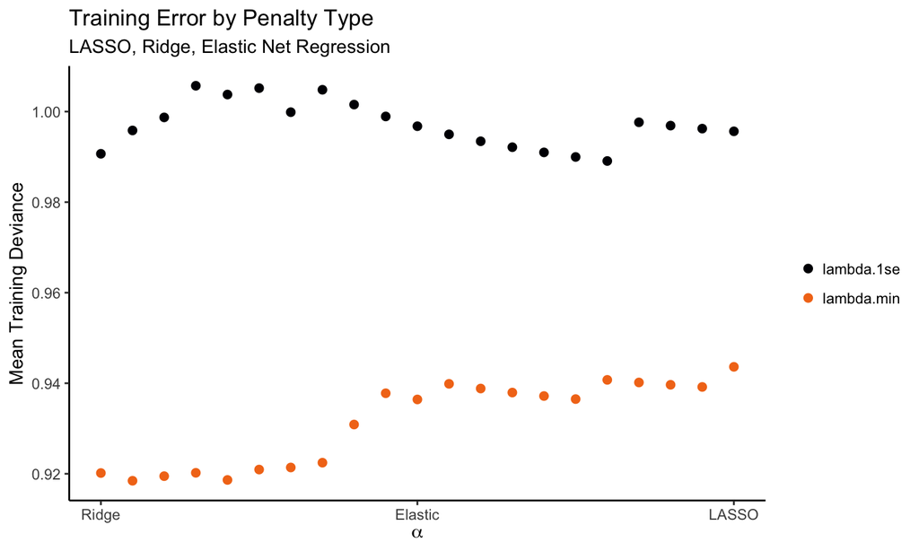

## Test Results

```r
best_alpha <- train_results %>%
    filter(lambda == "lambda.1se") %>%
    top_n(n = 1, wt = -train_dev) %>%
    pull(alpha)
best_alpha
```

```
## [1] 0.8
```

## Test Results

```r
test_results <- train_results %>%
    filter(alpha == best_alpha) %>%
    mutate(test_preds = map2(model,
                             lambda,
                             ~ predict(.x,
                                       newx = Xtest,
                                       type = "response",
                                       s = .y))) %>%
    mutate(test_dev = map_dbl(test_preds,
                              binom_deviance,
                              actual = ytest))
```

## Test Results

```r
test_results %>%
    select(lambda, train_dev, test_dev, everything())
```

```
## # A tibble: 2 x 7
##   lambda    train_dev test_dev alpha model       train_preds   test_preds
##   <chr>         <dbl>    <dbl> <dbl> <list>      <list>        <list>
## 1 lambda.m…     0.941    0.969   0.8 <S3: cv.gl… <dbl [800 × … <dbl [200 ×…
## 2 lambda.1…     0.989    0.977   0.8 <S3: cv.gl… <dbl [800 × … <dbl [200 ×…
```

## Plot Test Results

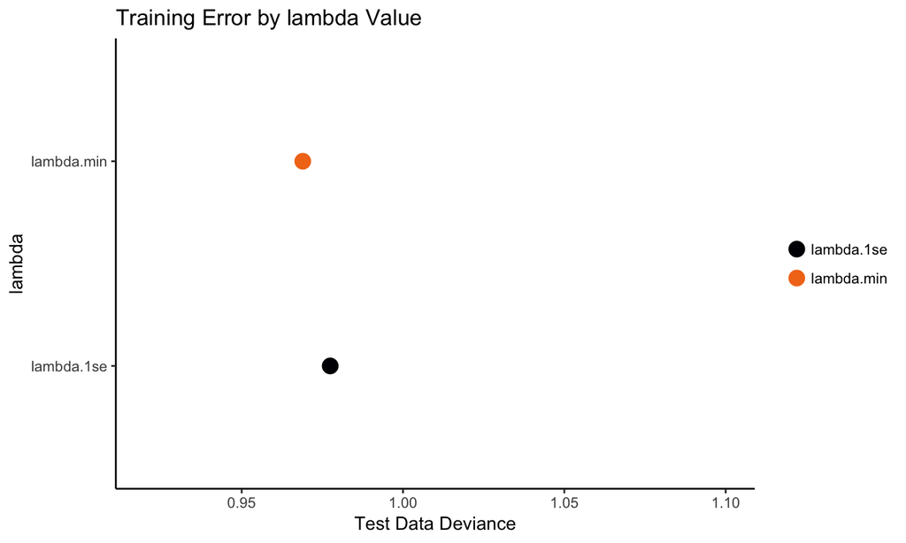

## Where next?

## Where next with `purrr` and Functional Programming?

- To learn about `purrr`: [Jenny Bryan’s tutorials](https://jennybc.github.io/purrr-tutorial/)
- For more on FP in R: [Hadley Wickham’s Advanced R](http://adv-r.had.co.nz/)
- Further reading on FP Principles: [Structure and Interpretation of Computer Programs](https://mitpress.mit.edu/sites/default/files/sicp/index.html), AKA *The Wizard Book*. (Also check out the accompanying [video lectures](https://www.youtube.com/watch?v=2Op3QLzMgSY&list=PLE18841CABEA24090), and enjoy the 1986 vibes.)
- This presentation available at [GitHub](https://github.com/hamedbh/func-prog)